# Reproducible Research: Peer Assessment 1

## Loading and preprocessing the data

Loading the data from the file is straightforward: activity.zip will be unzipped and loaded. Additionally, I am supressing the results, which are a bunch of useless warnings.

```r
library(Hmisc)
library(lubridate)
library(dplyr)

activity <- read.csv(unzip("activity.zip"), stringsAsFactors=FALSE)

# the data is a string, parsing it to a date
activity$date <- parse_date_time(activity$date, "Ymd")

#for some tasks the NA can be ignored, doing this here
activiy_withoutNA <- activity[complete.cases(activity),]
```

## What is mean total number of steps taken per day?

### Histogram of the total number of steps taken per day

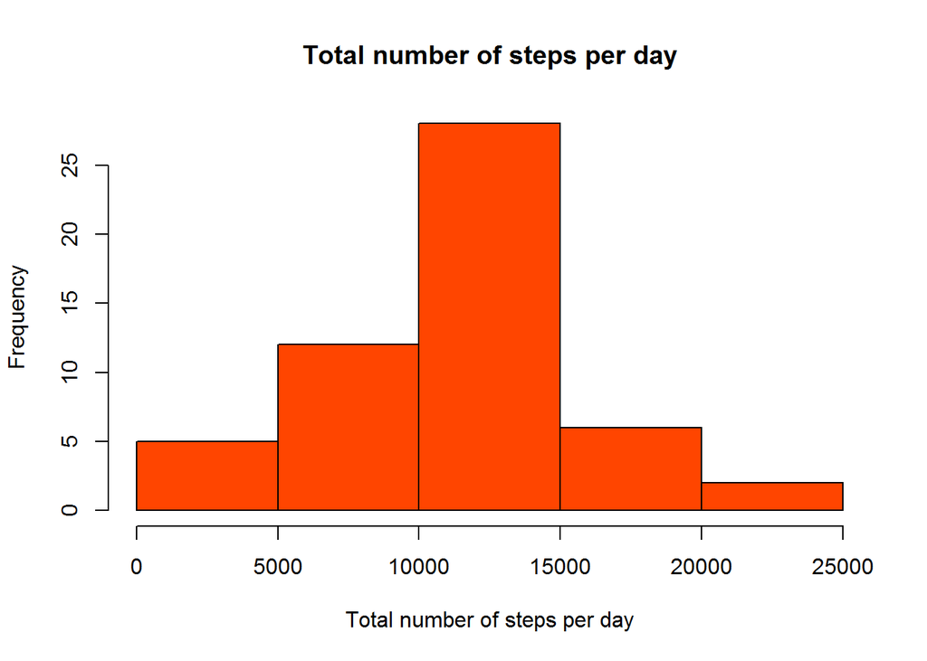

```r
#grouping by date
stepsPerDay <- group_by(activiy_withoutNA, date)
stepsPerDay <- summarise(stepsPerDay, totalSteps = sum(steps))

#creating the histogram
hist(stepsPerDay$totalSteps, xlab="Total number of steps per day", main="Total number of steps per day", col="orangered1")
```

### Mean / median steps per day

The mean number of the steps taken par day is: **10766.19**.

The median number of the steps taken par day is: **10765**.

## What is the average daily activity pattern?

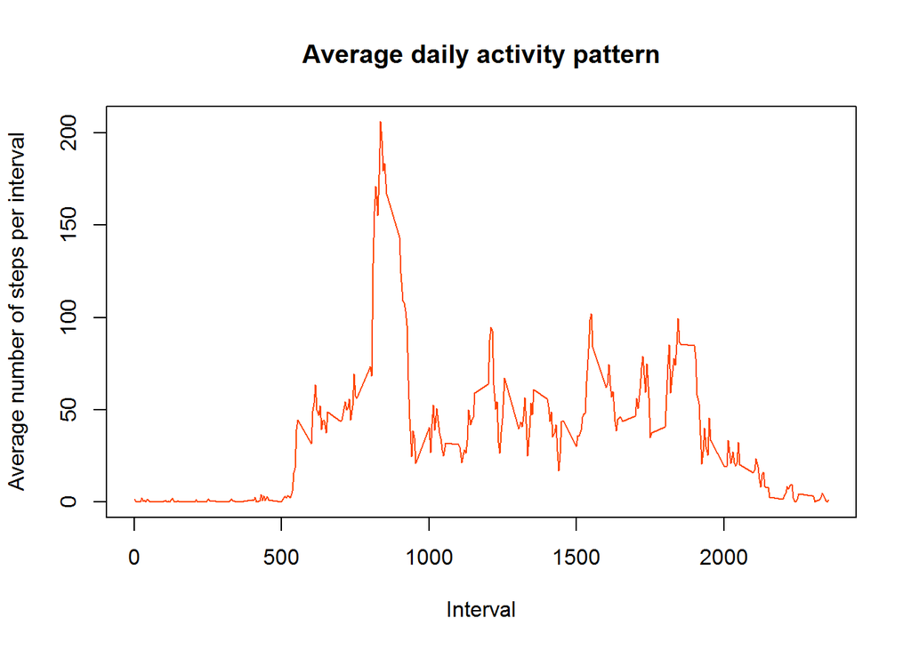

```r
#Compute the average per interval -> average across all days
stepsPerInterval <- group_by(activiy_withoutNA, interval)
stepsPerInterval <- summarise(stepsPerInterval, Steps = mean(steps))

#the lineplot itself
plot(stepsPerInterval$interval, stepsPerInterval$Steps, type="l", xlab="Interval", ylab="Average number of steps per interval" , main="Average daily activity pattern", col="orangered1")
```

```r
#reordering by the number of steps, for the second result
stepsPerInterval <- arrange(stepsPerInterval, desc(Steps))
```

## Imputing missing values

### Number of missing values

There are 17568 cases in total, but 2304 are containing missing values. Therefore, only 15264 cases are usable without imputation.

### Imputing missing values

Imputation of missing values is a complex field, where replacing missing values with the mean is normally a bad strategy. Unfortunately, more complex methods are relying on information about reason for missing values and / or additional variables which can help to predict the missing values. Since the dataset does not contain such additional information, I will go with the easy method and just use the mean - but that should NOT be done in production code.

```r
#using the Hmisc impute method for convienience, but a manual replacement would have been easy to do.
activityImputed<-activity
activityImputed$steps <- as.numeric(impute(activity$steps, mean))

stepsPerDayImputed <- group_by(activityImputed, date)
stepsPerDayImputed <- summarise(stepsPerDayImputed, totalSteps = sum(steps))
```

The mean number of steps *after* imputation: **10766.19**. The standard deviation of the original data: **4269.18** and from the imputed data: **3974.39**

The median number of the steps *after* imputation: **10766.19**.

If you take a look at the histogram with imputed values:

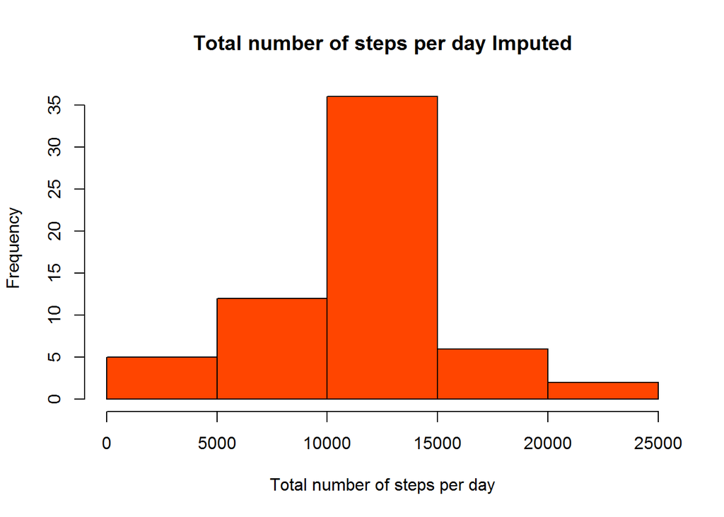

```r
hist(stepsPerDayImputed$totalSteps, xlab="Total number of steps per day", main="Total number of steps per day Imputed", col="orangered1")
```

You will see that the distribution has not dramatically changed, but there are a lot more days in the central column - indicating a highly mesokurtic (peaked) distribution. Thes empahsizes the problem of the mean substitution: the whole distribution gets “smaller” and centers around the peak.

## Are there differences in activity patterns between weekdays and weekends?

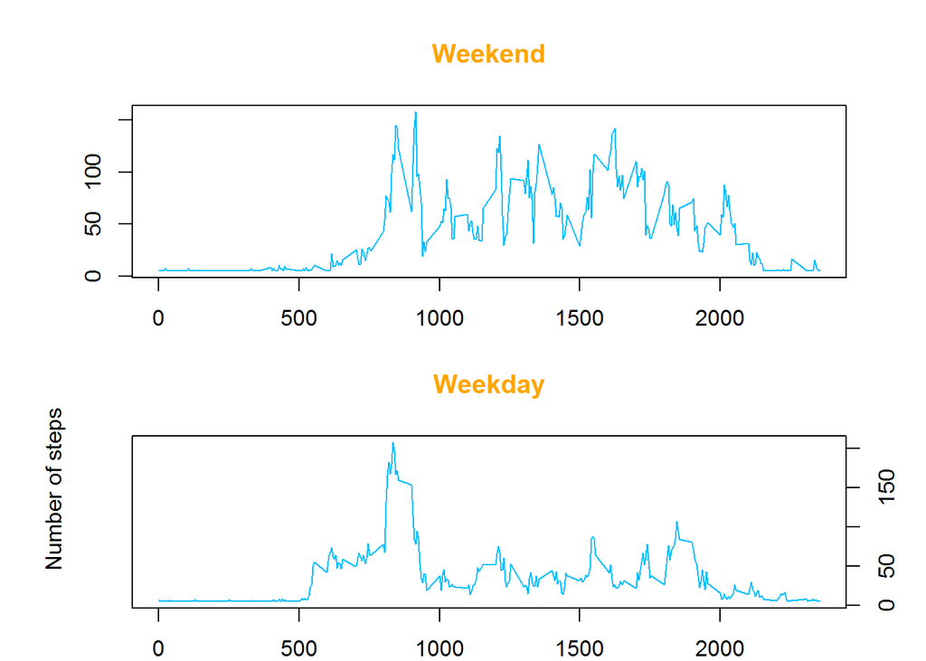

```r
#compute the weekday
activityImputed$Weekday <- wday(activityImputed$date, label=TRUE)

isWeekDay <- function(x)
{
  x <- as.character(x)
  if (x=="Sun" || x=="Sat")
  {
    return ("Weekend")
  }
  else
  {
    return ("Weekday")
  }
}

activityImputed$Weekend <- sapply(activityImputed$Weekday, isWeekDay)

#compute the factor called Weekend with the labels Weekend and Weekday
activityImputed[, 'Weekend'] <- as.factor(activityImputed[, 'Weekend'])

stepsPerIntervalWeekday <- group_by(activityImputed[activityImputed$Weekend=="Weekday",], interval)
stepsPerIntervalWeekday <- summarise(stepsPerIntervalWeekday, Steps = mean(steps))

stepsPerIntervalWeekend <- group_by(activityImputed[activityImputed$Weekend=="Weekend",], interval)
stepsPerIntervalWeekend <- summarise(stepsPerIntervalWeekend, Steps = mean(steps))

#the plot. Looks somewhat different since I did not use lattice
par(mfrow=c(2,1), mar=c(2,5,4,3))
plot(stepsPerIntervalWeekend$interval, stepsPerIntervalWeekend$Steps, type="l", xlab="", ylab="", col="deepskyblue", main="Weekend" ,col.main="orange")

plot(stepsPerIntervalWeekday$interval, stepsPerIntervalWeekday$Steps,col="deepskyblue", type="l", xlab="Interval", ylab="",yaxt='n', main="Weekday" ,col.main="orange")
axis(side = 4)
mtext("Number of steps", side = 2, adj=3.5, padj=-4)
```